# Large n, Large p: Statistical and Computational Challenges

When Many Samples Meet Many Features

Rod Albuyeh

2025-10-13

## Today’s Learning Goals

By the end of this session, you’ll understand:

- **Large n vs Large p**: Different challenges, different solutions
- **The curse of dimensionality**: Why more features ≠ better models
- **Computational complexity**: How data size affects algorithm choice
- **Statistical considerations**: Sampling, bias, and inference at scale
- **Policy implications**: When big data helps (and when it doesn’t)

**Important**

**Key insight**: The size and structure of your data fundamentally determines what methods you can use and what conclusions you can draw.

# Part I: Defining the Data Landscape

## The Two Faces of “Large Data”

Data can be large in fundamentally different ways:

**Large n (Many Observations)**

- **Millions of rows**
- **Systems challenges**: Storage, I/O, distributed computing
- **Statistical benefits**: Law of large numbers, central limit theorem
- **Examples**: Transaction logs, sensor data, administrative records

**Large p (Many Features)**

- **Thousands of variables**
- **Statistical challenges**: Overfitting, multiple testing, sparsity
- **Computational benefits/costs**: Parallel processing across features
- **Examples**: Genomics, text analysis, survey data, satellite imagery

**Critical distinction**: These require completely different analytical approaches and have different implications for inference.

## The n × p Matrix: A Framework

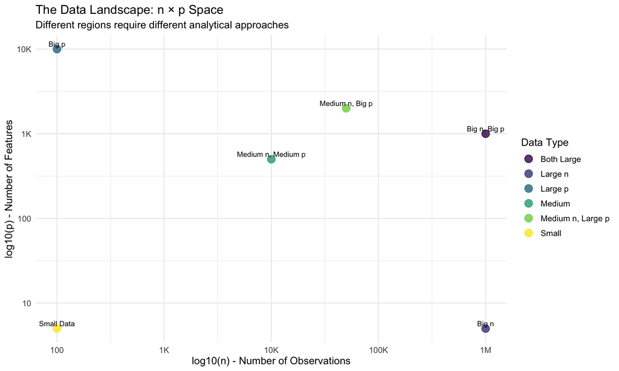

## Classical Statistics: The Small n, Small p World

**Traditional assumptions** (n = 100s, p = 10s):

- n >> p (much more data than parameters)
- Features are independent or nearly so
- Linear relationships dominate
- Normal distributions are common
- Significance testing is straightforward

**Methods that work well:** - Linear/logistic regression - t-tests, ANOVA - Classical hypothesis testing - Maximum likelihood estimation

**Policy context**: Randomized controlled trials, small-scale surveys, laboratory experiments

## Large n: The Promise and Peril

**Benefits of many observations:**

- **Statistical power**: Detect smaller effect sizes
- **Precision**: Narrower confidence intervals
- **Robustness**: Central limit theorem kicks in
- **Rare events**: Can study low-probability outcomes

**New challenges:**

- **Computational**: Algorithms that scale O(n²) become infeasible
- **Storage**: Memory limitations, disk I/O bottlenecks
- **Statistical significance vs practical significance**: Everything becomes “significant”
- **Data quality**: More observations ≠ better quality

**Example**: 10 million credit card transactions - Can detect fraud patterns invisible in small samples - But requires distributed computing and careful quality control

## Large p: The Curse of Dimensionality

**What happens when p approaches n?**

- **Overfitting**: Models memorize noise instead of learning patterns
- **Multiple testing**: False discovery rate explodes
- **Sparsity**: Most features are irrelevant
- **Distance metrics break down**: All points become equidistant

**Mathematical reality**: With p = 1000 features and n = 100 observations:

- Perfect fit is always possible (infinite solutions)
- Out-of-sample performance typically terrible
- Traditional inference breaks down

**Policy example**: Survey with 500 questions, 200 respondents - Can “predict” any outcome perfectly in-sample - Predictions on new data will be random - Need regularization, feature selection, or more data

# Part II: Statistical Challenges at Scale

## The Multiple Testing Problem

**The setup**: Testing 1000 features for association with an outcome

```r
# Simulate the multiple testing problem
set.seed(123)
n_tests <- 1000
n_obs <- 100

# Generate completely random data (no true associations)
p_values <- replicate(n_tests, {
  x <- rnorm(n_obs)  # Random predictor
  y <- rnorm(n_obs)  # Random outcome
  t.test(y ~ (x > median(x)))$p.value
})

# Count "significant" results
significant_05 <- sum(p_values < 0.05)
significant_01 <- sum(p_values < 0.01)

cat("Out of", n_tests, "completely random tests:\n")
```

```
Out of 1000 completely random tests:
```

```r
cat("- Significant at p < 0.05:", significant_05, "(expected ~50)\n")
```

```
- Significant at p < 0.05: 48 (expected ~50)
```

```r
cat("- Significant at p < 0.01:", significant_01, "(expected ~10)\n")
```

```
- Significant at p < 0.01: 6 (expected ~10)
```

**The problem**: With no true effects, we still find ~50 “significant” results at α = 0.05!

## The Bias-Variance Tradeoff in High Dimensions

**Classical tradeoff**:

- **Bias**: How far off is our average prediction?
- **Variance**: How much do predictions vary across samples?
- **Goal**: Minimize total error = Bias² + Variance + Irreducible Error

**In high dimensions** (large p):

- **Low bias, high variance**: Complex models fit training data perfectly but generalize poorly
- **High bias, low variance**: Simple models underfit but are consistent
- **Sweet spot**: Regularization finds the optimal tradeoff

**Policy implication**: A simple model that works consistently across contexts may be better than a complex model that’s perfect in one setting but fails elsewhere.

## Regularization: Taming High-Dimensional Data

**The problem**: Ordinary least squares with p ≈ n gives unstable estimates

**Ridge Regression** (L2 penalty):

- Shrinks coefficients toward zero
- Keeps all features but reduces their impact
- Good when many features are somewhat relevant

**Lasso Regression** (L1 penalty):

- Forces some coefficients to exactly zero
- Automatic feature selection
- Good when most features are irrelevant

**Elastic Net** combines L1 and L2 penalties, balances feature selection with stability, often the practical choice.

# Part III: Computational Considerations

## Algorithmic Complexity: Why Size Matters

**Big O notation** describes how runtime scales with data size:

**Common Complexities**

- **O(1)**: Constant time
- **O(log n)**: Logarithmic
- **O(n)**: Linear
- **O(n log n)**: Log-linear
- **O(n²)**: Quadratic
- **O(n³)**: Cubic
- **O(2ⁿ)**: Exponential

**Real-World Impact**

- **Linear regression**: O(np²)
- **k-means clustering**: O(nkt) iterations
- **Random forest**: O(n log n × p × trees)
- **Deep learning**: O(depends…)

**Example**: Matrix inversion is O(p³). With p = 10,000 features, that’s 10¹² operations!

## Big 0 Visualized

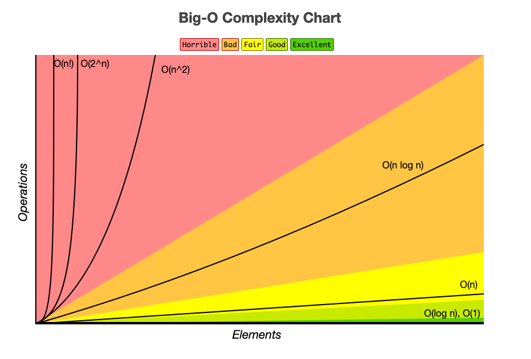

## Memory vs Computation Tradeoffs

```r
# Demonstrate memory scaling
data_sizes <- tibble(
  n = c(1000, 10000, 100000, 1000000),
  p = c(10, 100, 1000, 10000),
  memory_gb = (n * p * 8) / (1024^3),  # 8 bytes per double
  matrix_ops = (p^3) / 1e9  # Billions of operations for matrix inversion
)

knitr::kable(data_sizes,
             col.names = c("Observations", "Features", "Memory (GB)", "Matrix Ops (Billions)"),
             digits = c(0, 0, 3, 1),
             caption = "Memory and Computational Requirements")
```

Memory and Computational Requirements

| Observations | Features | Memory (GB) | Matrix Ops (Billions) |
| --- | --- | --- | --- |
| 1e+03 | 10 | 0.000 | 0 |
| 1e+04 | 100 | 0.007 | 0 |
| 1e+05 | 1000 | 0.745 | 1 |
| 1e+06 | 10000 | 74.506 | 1000 |

**Key insight**: Memory scales linearly (n×p), but many algorithms scale polynomially or worse in p.

## Distributed Computing: When One Machine Isn’t Enough

**MapReduce paradigm**:

1. **Map**: Apply function to chunks of data in parallel
2. **Reduce**: Combine results from all chunks
3. **Repeat**: Until convergence or completion

**What works well**:

- Simple aggregations (sums, means, counts)
- Embarrassingly parallel problems
- Algorithms that can be decomposed into independent steps

**What doesn’t**:

- Algorithms requiring global information, iterative methods with dependencies, complex joins or sorts

# Part IV: The Quality vs Quantity Debate

## Case Study: The Literary Digest Disaster (1936)

**The setup**:

- Literary Digest magazine conducts presidential poll
- Sends 10+ million survey cards
- Receives 2.4 million responses (24% response rate)
- **Massive sample size** for 1936!

**The prediction**: Alf Landon defeats Franklin Roosevelt 57% to 43%

**The reality**: Roosevelt wins 61% to 37% - one of the biggest landslides in US history

**What went wrong?**

- **Sample frame bias**: Telephone directories and car registrations (wealthy people)
- **Non-response bias**: Republicans more likely to respond
- **Big ≠ representative**: 2.4 million biased responses < 50,000 random responses

## Modern Parallels: When Big Data Fails

**Google Flu Trends (2009-2015)**:

- Used search queries to predict flu outbreaks
- Initially very successful
- Gradually became less accurate as search behavior changed
- **Lesson**: Behavioral data can be non-stationary

**2016 Election Polling**:

- Massive online samples
- Still missed key demographic shifts
- **Lesson**: Coverage bias persists even with large samples

## The Data Generating Process: A Framework for Thinking

**Key questions for any large dataset**:

1. **Who/what is included?** (Coverage)
2. **Who/what is missing?** (Selection bias)
3. **How was it collected?** (Measurement process)
4. **Why was it collected?** (Original purpose vs your purpose)
5. **When was it collected?** (Temporal stability)
6. **How does it relate to your target population?** (External validity)

**Policy example**: Using cell phone location data to study mobility. **Included**: Smartphone users with location services enabled. **Missing**: Elderly, low-income, privacy-conscious individuals. **Bias**: Overrepresents young, urban, tech-savvy population

# Part V: Statistical Learning in High Dimensions

## The Fundamental Tradeoff: Flexibility vs Interpretability

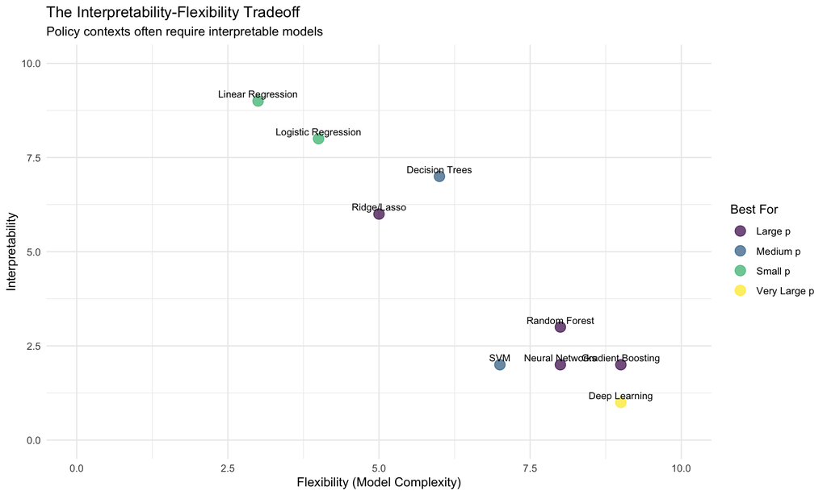

## Model Validation: Beyond Training Accuracy

**Why traditional methods fail in high dimensions**:

- Training error always decreases with model complexity
- R² can always reach 1.0 with enough parameters
- Statistical significance becomes meaningless

**The fundamental principle**: Always test on data the model hasn’t seen during training

**The stakes**: Wrong validation = wrong model selection = failed deployment

## Validation Strategy Selection

**Key question**: How will your model be used in practice?

**Data Structure Considerations**

- **Independent observations?** → Random splits
- **Time series?** → Temporal splits
- **Clustered data?** → Group-aware splits
- **Spatial data?** → Geographic splits
- **Imbalanced classes?** → Stratified splits

**Computational Constraints**

- **Large n, small compute?** → Simple hold-out
- **Small n, need precision?** → k-fold CV
- **Time series, need speed?** → Rolling window
- **Very large p?** → Nested CV with feature selection

## Common Validation Strategies

**Hold-out (70/15/15)**:

- **Best for**: Large datasets, limited compute time
- **Pros**: Fast, simple, mirrors real deployment
- **Cons**: Wastes data, high variance with small samples

**k-Fold Cross-Validation**:

- **Best for**: Medium datasets, i.i.d. assumptions hold
- **Pros**: Uses all data, stable estimates
- **Cons**: k×training time, assumes exchangeable observations

**Time Series Validation**:

- **Best for**: Temporal data, forecasting problems
- **Pros**: Respects time order, prevents data leakage
- **Cons**: Limited training data, requires careful design

## Advanced Validation Considerations

**Nested Cross-Validation**:

- **When**: Hyperparameter tuning + model selection
- **Why**: Prevents overfitting to validation set
- **Cost**: k×m×training time (expensive!)

**Group-Based Splits**:

- **Examples**: Patients in hospitals, students in schools, counties in states
- **Critical**: Prevents information leakage between related observations
- **Policy relevance**: Most policy data has hierarchical structure

**Computational Trade-offs**:

- **Large n**: Simple splits often sufficient
- **Large p**: Feature selection within CV folds
- **Both large**: Distributed computing, approximate methods

## Validation Pitfalls in Policy Research

**Data leakage examples**:

- Using future information to predict past events
- Including outcome-derived features
- Ignoring temporal dependencies in panel data
- Not accounting for policy implementation timing

**Domain mismatch**:

- Training on one population, deploying on another
- Different time periods (policy environment changes)
- Different geographic regions (local context matters)
- Different institutional settings

**Critical insight**: **Your validation strategy is a statement about how you believe your model will generalize.** Choose carefully.

## Feature Selection: Finding Signal in the Noise

**The challenge**: With p = 10,000 features, most are irrelevant noise

**Filter methods**: Rank features by correlation with outcome.Fast but ignores feature interactions. Good for initial screening.

**Wrapper methods**: Forward/backward selection based on model performance. Computationally expensive but considers interactions. Risk of overfitting with many features.

**Embedded methods**: Feature selection built into the algorithm (Lasso, Random Forest). Balance between speed and accuracy. Often the practical choice.

# Part VI: Policy Applications and Case Studies

## Case Study 1: Predicting Policy Outcomes

**Scenario**: City wants to predict which neighborhoods will benefit most from job training programs

**Large n approach** (Administrative data): - **Data**: 100,000 residents, 20 features - **Method**: Logistic regression, random forest - **Strength**: Reliable estimates for major demographic groups - **Weakness**: May miss important but rare subgroups

**Large p approach** (Survey + external data): - **Data**: 1,000 residents, 500 features (survey + census + business data) - **Method**: Lasso regression, elastic net - **Strength**: Can identify complex interaction patterns - **Weakness**: Estimates may not generalize to broader population

**Policy insight**: Large n better for implementation; large p better for discovery of new mechanisms

## Case Study 2: Fraud Detection at Scale

**The problem**: Detect fraudulent transactions in real-time - **Data**: Millions of transactions daily, hundreds of features - **Constraints**: Must decide in milliseconds - **Cost of errors**: False positives annoy customers, false negatives lose money

**Technical solution**: - **Feature engineering**: Create derived features (spending patterns, location anomalies) - **Ensemble methods**: Combine multiple simple models - **Online learning**: Update models as new data arrives - **A/B testing**: Continuously evaluate model performance

**Policy parallel**: Similar challenges in welfare fraud detection, tax compliance, regulatory monitoring

## The Reproducibility Crisis in Large-Scale Studies

**The problem**: Many “significant” findings from large datasets don’t replicate

**Contributing factors**: - **Multiple testing**: Fishing for significant results - **P-hacking**: Trying different specifications until something is significant - **Publication bias**: Only positive results get published - **Data snooping**: Using the same data for exploration and confirmation

**Solutions**: - **Pre-registration**: Specify hypotheses and analysis plan before seeing data - **Hold-out samples**: Reserve data for final validation - **Replication studies**: Test findings on independent datasets - **Robust standard errors**: Account for multiple testing and clustering

**Policy implication**: Be skeptical of any single study, even with large samples. Look for replication and robustness.

# Part VII: Practical Guidelines

## Decision Framework: Choosing Your Approach

**When n >> p (Large n, Small p)**

**Use:** - Classical statistical methods - Focus on causal inference - Emphasize external validity - Simple, interpretable models

**Examples:** - A/B tests with millions of users - Administrative data analysis - Policy evaluation studies

**When p >> n (Small n, Large p)**

**Use:** - Regularization methods - Cross-validation for model selection - Feature selection techniques - Be very cautious about generalization

**Examples:** - Genomics studies - Text analysis with small samples - Survey data with many questions

**When both n and p are large**: Use distributed computing, ensemble methods, and very careful validation procedures.

## Best Practices for Large-Scale Analysis

**Data quality**: - Understand the data generating process - Check for systematic biases and missing data patterns - Validate against external benchmarks when possible

**Model development**: - Always use proper train/validation/test splits - Cross-validate hyperparameter selection - Test robustness across different subgroups

**Interpretation**: - Focus on effect sizes, not just statistical significance - Consider practical significance for policy decisions - Acknowledge limitations and uncertainty

**Communication**: - Explain methods clearly to non-technical audiences - Visualize uncertainty and confidence intervals - Discuss what the analysis can and cannot tell us

## Common Pitfalls and How to Avoid Them

**“Big data solves everything”**

- **Reality**: Bias and poor measurement still matter
- **Solution**: Focus on data quality, not just quantity

**“More features = better predictions”**

- **Reality**: Curse of dimensionality, overfitting
- **Solution**: Use regularization and feature selection

**“Statistical significance = practical importance”**

- **Reality**: Large samples make everything “significant”
- **Solution**: Focus on effect sizes and confidence intervals

**“Correlation patterns reveal causation”**

- **Reality**: Confounding and selection bias persist at scale
- **Solution**: Use causal inference methods, natural experiments

## Looking Forward: Emerging Challenges

**Algorithmic fairness**: How do we ensure large-scale models don’t perpetuate bias?

**Privacy and ethics**: How do we balance analytical power with individual privacy?

**Interpretability**: How do we make complex models understandable to policymakers?

**Temporal stability**: How do we handle models that become obsolete as the world changes?

**Democratic accountability**: How do we govern algorithmic decision-making in public policy?

## Next Steps

**For Wednesday’s Lab 3:**

- **Loading and Storing Data Efficiently** - hands-on practice with large datasets
- Learn about data storage formats (Parquet, Arrow) for big data
- Practice efficient data workflows and reproducible analysis

**Before Wednesday, please read/watch:**

- **MDSR Ch. 1**: Why Data Science?
- **MDSR Ch. 21**: Towards “Big Data”
- **LAT Methodology**: Labor Action Tracker methodology
- **MDSR Appendix D**: Reproducible Analysis and Workflow
- **Video**: Store Your R Data in Apache Parquet Big Data Format

## Questions?

**Remember**: The size and structure of your data should drive your analytical approach.